# Aprendizado de Máquina Aplicada à Análise de Dados do COVID-19

- Professor: Filipe Verri
- Aluno: Paulo Giovani de Faria Zeferino

Este segundo notebook contém os passos da análise exploratória dos dados utilizados para o desenvolvimento do artigo **Aprendizado de Máquina Aplicada à Análise de Dados do COVID-19**, solicitado pelo professor Filipe Verri para a disciplina PO-233/2020 Aprendizado de Máquina, oferecida pelo curso de pós-graduação do ITA.

# 1. Importação das bibliotecas

```python
# Importa as bibliotecas
import pandas as pd
import numpy as np
import matplotlib
import matplotlib.pyplot as plt
import seaborn as sns
```

```python
# Configura os parâmetros do Matplotlib
%matplotlib inline

plt.rcParams.update({'font.size': 20,
                     'figure.figsize': (10, 8),
                     'figure.dpi': 90,
                     'savefig.dpi': 300,
                     'axes.grid': True,
                     'axes.axisbelow': True,
                     'grid.color': 'k',
                     'grid.linestyle': ':',
                     'grid.linewidth': 0.5,
                     'grid.alpha': 0.5})
```

# 2. Importação do arquivo de dados

```python
# Importa o arquivo de dados -> 'covid19.csv'
covid_df = pd.read_csv('data/artigo/covid19.csv')
```

# 3. Análise Exploratória de Dados

A Análise Exploratória de Dados (AED) é utilizada para que possamos entender, de maneira resumida, as principais características dos dados. De acordo com as informações que são reveladas, podemos discutir as principais problemáticas dos dados, as quais serão posteriormente tratadas em uma seção de pré-processamento.

O processo da AED é uma etapa crucial antes da construção de um modelo, a fim de desvendar várias idéias que mais tarde se tornam importantes no desenvolvimento de um modelo algorítmico robusto.

## 3.1 Observando o conjundo de dados

```python
# Exibe as dimensões do DataFrame
print("Dimensões do arquivo de dados:\n")
print(f"Total de linhas: {covid_df.shape[0]}")
print(f"Total de colunas: {covid_df.shape[1]}")
```

```
Dimensões do arquivo de dados:

Total de linhas: 22270
Total de colunas: 21
```

```python
# Habilita/Desabilita a opção para exibir todas as linhas
#pd.set_option('display.max_rows', None)
```

```python
# Exibe as primeiras 10 linhas do arquivo
covid_df.head(10)
```

|  | Código do País | País/Região | Província/Estado | Latitude | Longitude | PIB 2019 | População | População Urbana | Área (Km/2) | Densidade (Km/2) | ... | Média de Idade | Taxa de Fumantes | Taxa de Mortalidade por Doenças Pulmonares | Total de Leitos Hospitalares | Temperatura Média (Janeiro - Março) | Taxa de Umidade (Janeiro - Março) | Data do Primeiro Caso | Data | Casos Confirmados | Fatalidades |
| --- | --- | --- | --- | --- | --- | --- | --- | --- | --- | --- | --- | --- | --- | --- | --- | --- | --- | --- | --- | --- | --- |
| 0 | AFG | Afghanistan | NaN | 33.0000 | 65.0000 | 18734.0 | 38928346.0 | 25.0 | 652860.0 | 60.0 | ... | 18.0 | NaN | 37.62 | 0.5 | 6.216667 | 56.933333 | 2/23/2020 | 1/22/20 | 0 | 0 |
| 1 | ALB | Albania | NaN | 41.1533 | 20.1683 | 15418.0 | 2877797.0 | 63.0 | 27400.0 | 105.0 | ... | 36.0 | 29.40 | 11.67 | 2.9 | 13.950000 | 69.900000 | 3/7/2020 | 1/22/20 | 0 | 0 |
| 2 | DZA | Algeria | NaN | 28.0339 | 1.6596 | 172781.0 | 43851044.0 | 73.0 | 2381740.0 | 18.0 | ... | 29.0 | NaN | 8.77 | 1.9 | 19.566667 | 61.716667 | 2/24/2020 | 1/22/20 | 0 | 0 |
| 3 | AND | Andorra | NaN | 42.5063 | 1.5218 | 91527.0 | 77265.0 | 88.0 | 470.0 | 164.0 | ... | NaN | 32.50 | NaN | 2.5 | 7.383333 | 75.233333 | 3/1/2020 | 1/22/20 | 0 | 0 |
| 4 | NaN | Angola | NaN | -11.2027 | 17.8739 | NaN | 32866272.0 | 67.0 | 1246700.0 | 26.0 | ... | 17.0 | NaN | NaN | NaN | NaN | NaN | NaN | 1/22/20 | 0 | 0 |
| 5 | ATG | Antigua and Barbuda | NaN | 17.0608 | -61.7964 | 1688.0 | 97929.0 | 26.0 | 440.0 | 223.0 | ... | 34.0 | NaN | 11.76 | 3.8 | NaN | NaN | 3/12/2020 | 1/22/20 | 0 | 0 |
| 6 | ARG | Argentina | NaN | -38.4161 | -63.6167 | 445469.0 | 45195774.0 | 93.0 | 2736690.0 | 17.0 | ... | 32.0 | 23.95 | 29.27 | 5.0 | 32.816667 | 43.616667 | 3/2/2020 | 1/22/20 | 0 | 0 |
| 7 | ARM | Armenia | NaN | 40.0691 | 45.0382 | 13444.0 | 2963243.0 | 63.0 | 28470.0 | 104.0 | ... | 35.0 | 26.90 | 23.86 | 4.2 | 7.100000 | 58.500000 | 2/29/2020 | 1/22/20 | 0 | 0 |
| 8 | AUS | Australia | Australian Capital Territory | -35.4735 | 149.0124 | 1376255.0 | 25499884.0 | 86.0 | 7682300.0 | 3.0 | ... | 38.0 | 14.90 | 18.79 | 3.8 | 25.783333 | 64.233333 | 1/24/2020 | 1/22/20 | 0 | 0 |
| 9 | AUS | Australia | New South Wales | -33.8688 | 151.2093 | 1376255.0 | 25499884.0 | 86.0 | 7682300.0 | 3.0 | ... | 38.0 | 14.90 | 18.79 | 3.8 | 25.783333 | 64.233333 | 1/24/2020 | 1/22/20 | 0 | 0 |

10 rows × 21 columns

```python
# Exibe as 10 últimas linhas do arquivo
covid_df.tail(10)
```

|  | Código do País | País/Região | Província/Estado | Latitude | Longitude | PIB 2019 | População | População Urbana | Área (Km/2) | Densidade (Km/2) | ... | Média de Idade | Taxa de Fumantes | Taxa de Mortalidade por Doenças Pulmonares | Total de Leitos Hospitalares | Temperatura Média (Janeiro - Março) | Taxa de Umidade (Janeiro - Março) | Data do Primeiro Caso | Data | Casos Confirmados | Fatalidades |
| --- | --- | --- | --- | --- | --- | --- | --- | --- | --- | --- | --- | --- | --- | --- | --- | --- | --- | --- | --- | --- | --- |
| 22260 | NaN | Burundi | NaN | -3.373100 | 29.918900 | NaN | 11890784.0 | 14.0 | 25680.0 | 463.0 | ... | 17.0 | NaN | NaN | NaN | NaN | NaN | NaN | 4/15/20 | 5 | 1 |
| 22261 | NaN | Sierra Leone | NaN | 8.460555 | -11.779889 | NaN | 7976983.0 | 43.0 | 72180.0 | 111.0 | ... | 19.0 | NaN | NaN | NaN | NaN | NaN | NaN | 4/15/20 | 13 | 0 |
| 22262 | NLD | Netherlands | Bonaire, Sint Eustatius and Saba | 12.178400 | -68.238500 | 902355.0 | 17134872.0 | 92.0 | 33720.0 | 508.0 | ... | 43.0 | 25.05 | 26.00 | 4.7 | 8.983333 | 78.133333 | 2/26/2020 | 4/15/20 | 3 | 0 |
| 22263 | NaN | Malawi | NaN | -13.254308 | 34.301525 | NaN | 19129952.0 | 18.0 | 94280.0 | 203.0 | ... | 18.0 | NaN | NaN | NaN | NaN | NaN | NaN | 4/15/20 | 16 | 2 |
| 22264 | GBR | United Kingdom | Falkland Islands (Malvinas) | -51.796300 | -59.523600 | 2743586.0 | 67886011.0 | 83.0 | 241930.0 | 281.0 | ... | 40.0 | 19.15 | 23.66 | 2.8 | 6.433333 | 74.583333 | 1/30/2020 | 4/15/20 | 11 | 0 |
| 22265 | FRA | France | Saint Pierre and Miquelon | 46.885200 | -56.315900 | 2707074.0 | 65273511.0 | 82.0 | 547557.0 | 119.0 | ... | 42.0 | 27.70 | 13.15 | 6.5 | 11.266667 | 72.950000 | 1/23/2020 | 4/15/20 | 1 | 0 |
| 22266 | NaN | South Sudan | NaN | 6.877000 | 31.307000 | NaN | 11193725.0 | 25.0 | 610952.0 | 18.0 | ... | 19.0 | NaN | NaN | NaN | NaN | NaN | NaN | 4/15/20 | 4 | 0 |
| 22267 | NaN | Western Sahara | NaN | 24.215500 | -12.885800 | NaN | 597339.0 | 87.0 | 266000.0 | 2.0 | ... | 28.0 | NaN | NaN | NaN | NaN | NaN | NaN | 4/15/20 | 6 | 0 |
| 22268 | NaN | Sao Tome and Principe | NaN | 0.186360 | 6.613081 | NaN | NaN | NaN | NaN | NaN | ... | NaN | NaN | NaN | NaN | NaN | NaN | NaN | 4/15/20 | 4 | 0 |
| 22269 | NaN | Yemen | NaN | 15.552727 | 48.516388 | NaN | 29825964.0 | 38.0 | 527970.0 | 56.0 | ... | 20.0 | NaN | NaN | NaN | NaN | NaN | NaN | 4/15/20 | 1 | 0 |

10 rows × 21 columns

```python
# Descreve os tipos de dados de cada atributo
covid_df.dtypes
```

```
Código do País                                 object
País/Região                                    object
Província/Estado                               object
Latitude                                      float64
Longitude                                     float64
PIB 2019                                      float64
População                                     float64
População Urbana                              float64
Área (Km/2)                                   float64
Densidade (Km/2)                              float64
Taxa de Fertilidade                           float64
Média de Idade                                float64
Taxa de Fumantes                              float64
Taxa de Mortalidade por Doenças Pulmonares    float64
Total de Leitos Hospitalares                  float64
Temperatura Média (Janeiro - Março)           float64
Taxa de Umidade (Janeiro - Março)             float64
Data do Primeiro Caso                          object
Data                                           object
Casos Confirmados                               int64
Fatalidades                                     int64
dtype: object
```

```python
# Ajusta a quantidade de casas decimais
#pd.set_option('display.float_format', lambda x: '%.4f' % x)
```

```python
# Exibe a estatística descritiva do DataFrame, incluindo as colunas categóricas
covid_df.describe(include='all')
```

|  | Código do País | País/Região | Província/Estado | Latitude | Longitude | PIB 2019 | População | População Urbana | Área (Km/2) | Densidade (Km/2) | ... | Média de Idade | Taxa de Fumantes | Taxa de Mortalidade por Doenças Pulmonares | Total de Leitos Hospitalares | Temperatura Média (Janeiro - Março) | Taxa de Umidade (Janeiro - Março) | Data do Primeiro Caso | Data | Casos Confirmados | Fatalidades |
| --- | --- | --- | --- | --- | --- | --- | --- | --- | --- | --- | --- | --- | --- | --- | --- | --- | --- | --- | --- | --- | --- |
| count | 20995 | 22270 | 6800 | 22270.000000 | 22270.000000 | 2.099500e+04 | 2.125000e+04 | 20825.000000 | 2.125000e+04 | 21250.000000 | ... | 20740.000000 | 16915.000000 | 20315.000000 | 20995.000000 | 18615.000000 | 18615.000000 | 20995 | 22270 | 22270.000000 | 22270.000000 |
| unique | 169 | 185 | 80 | NaN | NaN | NaN | NaN | NaN | NaN | NaN | ... | NaN | NaN | NaN | NaN | NaN | NaN | 48 | 85 | NaN | NaN |
| top | CHN | China | Bermuda | NaN | NaN | NaN | NaN | NaN | NaN | NaN | ... | NaN | NaN | NaN | NaN | NaN | NaN | 1/10/2020 | 3/16/20 | NaN | NaN |
| freq | 2805 | 2805 | 85 | NaN | NaN | NaN | NaN | NaN | NaN | NaN | ... | NaN | NaN | NaN | NaN | NaN | NaN | 2805 | 262 | NaN | NaN |
| mean | NaN | NaN | NaN | 21.480054 | 22.337539 | 2.543497e+06 | 2.225719e+08 | 64.702041 | 2.386026e+06 | 305.028000 | ... | 33.500000 | 21.898492 | 28.760962 | 3.407790 | 15.581126 | 65.073592 | NaN | NaN | 1481.740144 | 79.564122 |
| std | NaN | NaN | NaN | 24.712085 | 70.779624 | 4.827528e+06 | 4.839084e+08 | 20.319098 | 3.762297e+06 | 1749.463317 | ... | 8.564572 | 7.623802 | 18.779781 | 2.257748 | 10.830042 | 16.848413 | NaN | NaN | 14556.717948 | 890.463746 |
| min | NaN | NaN | NaN | -51.796300 | -135.000000 | 5.930000e+02 | 8.010000e+02 | 13.000000 | 0.000000e+00 | 2.000000 | ... | 15.000000 | 3.700000 | 6.290000 | 0.100000 | -9.883333 | 10.983333 | NaN | NaN | 0.000000 | 0.000000 |
| 25% | NaN | NaN | NaN | 7.540000 | -23.041800 | 2.391800e+04 | 5.106626e+06 | 55.000000 | 5.439000e+04 | 32.000000 | ... | 27.750000 | 15.000000 | 17.810000 | 1.600000 | 8.983333 | 52.083333 | NaN | NaN | 0.000000 | 0.000000 |
| 50% | NaN | NaN | NaN | 23.659750 | 20.921188 | 2.469530e+05 | 2.115826e+07 | 64.000000 | 3.050600e+05 | 109.500000 | ... | 38.000000 | 23.450000 | 22.340000 | 2.900000 | 11.266667 | 71.400000 | NaN | NaN | 2.000000 | 0.000000 |
| 75% | NaN | NaN | NaN | 41.204400 | 81.000000 | 1.730914e+06 | 6.527351e+07 | 82.000000 | 1.943950e+06 | 153.000000 | ... | 40.250000 | 25.550000 | 32.010000 | 4.200000 | 25.783333 | 77.000000 | NaN | NaN | 113.000000 | 1.000000 |
| max | NaN | NaN | NaN | 71.706900 | 178.065000 | 2.143945e+07 | 1.439324e+09 | 98.000000 | 1.637687e+07 | 26337.000000 | ... | 48.000000 | 42.650000 | 114.280000 | 13.800000 | 40.150000 | 92.316667 | NaN | NaN | 636350.000000 | 28326.000000 |

11 rows × 21 columns

## 3.2 Verificando zeros e NaN

```python
# Exibe o número de observações distintas para cada coluna do DataFrame
covid_df.nunique()
```

```
Código do País                                 169
País/Região                                    185
Província/Estado                                80
Latitude                                       254
Longitude                                      257
PIB 2019                                       170
População                                      173
População Urbana                                74
Área (Km/2)                                    173
Densidade (Km/2)                               126
Taxa de Fertilidade                             47
Média de Idade                                  34
Taxa de Fumantes                               112
Taxa de Mortalidade por Doenças Pulmonares     160
Total de Leitos Hospitalares                    68
Temperatura Média (Janeiro - Março)            135
Taxa de Umidade (Janeiro - Março)              136
Data do Primeiro Caso                           48
Data                                            85
Casos Confirmados                             2335
Fatalidades                                    652
dtype: int64
```

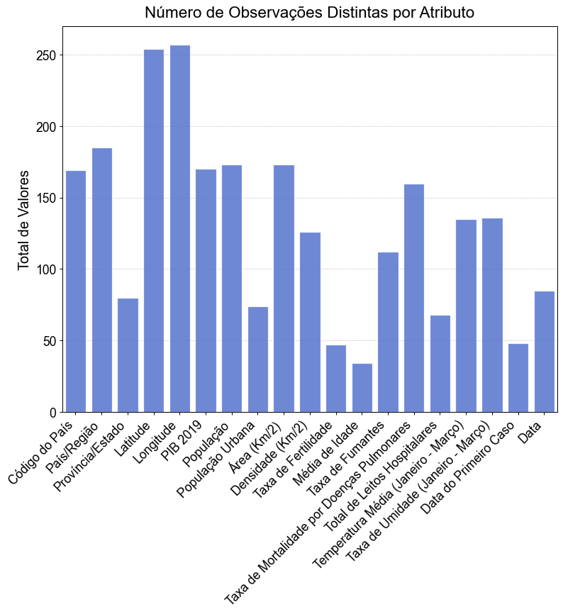

```python
# Exibe um gráfico de barras com esses valores

# Número de observações distintas para cada coluna do DataFrame
valores = covid_df.nunique()
valores = valores[:-2]

# Plotagem
fig, ax = plt.subplots(figsize=(10, 8));

sns.set(style='whitegrid');
ax = sns.barplot(x=valores.index, y=valores, color='royalblue', alpha=0.85);
ax.set_title("Número de Observações Distintas por Atributo", fontsize = 18, y=1.01);
ax.set_ylabel('Total de Valores', fontsize=16);
ax.set_xticklabels(valores.index, rotation=45, ha='right');
ax.tick_params(axis='x', labelsize=14, rotation=45 );
ax.tick_params(axis='y', labelsize=14);

# Salva a figura
plt.savefig('imagens/numero_observacoes.png', dpi=300, transparent=True, bbox_inches='tight')
```

```python
# Exibe informações sobre os tipos de dados e valores não nulos de cada coluna
# Repare que as datas não estão sendo armazenadas com o tipo de dados adequado
covid_df.info()
```

```
<class 'pandas.core.frame.DataFrame'>
RangeIndex: 22270 entries, 0 to 22269
Data columns (total 21 columns):
 #   Column                                      Non-Null Count  Dtype
---  ------                                      --------------  -----
 0   Código do País                              20995 non-null  object
 1   País/Região                                 22270 non-null  object
 2   Província/Estado                            6800 non-null   object
 3   Latitude                                    22270 non-null  float64
 4   Longitude                                   22270 non-null  float64
 5   PIB 2019                                    20995 non-null  float64
 6   População                                   21250 non-null  float64
 7   População Urbana                            20825 non-null  float64
 8   Área (Km/2)                                 21250 non-null  float64
 9   Densidade (Km/2)                            21250 non-null  float64
 10  Taxa de Fertilidade                         20740 non-null  float64
 11  Média de Idade                              20740 non-null  float64
 12  Taxa de Fumantes                            16915 non-null  float64
 13  Taxa de Mortalidade por Doenças Pulmonares  20315 non-null  float64
 14  Total de Leitos Hospitalares                20995 non-null  float64
 15  Temperatura Média (Janeiro - Março)         18615 non-null  float64
 16  Taxa de Umidade (Janeiro - Março)           18615 non-null  float64
 17  Data do Primeiro Caso                       20995 non-null  object
 18  Data                                        22270 non-null  object
 19  Casos Confirmados                           22270 non-null  int64
 20  Fatalidades                                 22270 non-null  int64
dtypes: float64(14), int64(2), object(5)
memory usage: 3.6+ MB
```

```python
# Exibe o total de valores ausentes de cada coluna
covid_df.isnull().sum()#.sort_values(ascending = False)
```

```
Código do País                                 1275
País/Região                                       0
Província/Estado                              15470
Latitude                                          0
Longitude                                         0
PIB 2019                                       1275
População                                      1020
População Urbana                               1445
Área (Km/2)                                    1020
Densidade (Km/2)                               1020
Taxa de Fertilidade                            1530
Média de Idade                                 1530
Taxa de Fumantes                               5355
Taxa de Mortalidade por Doenças Pulmonares     1955
Total de Leitos Hospitalares                   1275
Temperatura Média (Janeiro - Março)            3655
Taxa de Umidade (Janeiro - Março)              3655
Data do Primeiro Caso                          1275
Data                                              0
Casos Confirmados                                 0
Fatalidades                                       0
dtype: int64
```

```python
# Função que retorna a quantidade de zeros e NaN de cada coluna
def missing_zero_values_table(df):

    # Total de valores zero e valores ausentes
    zeros = (df == 0.00).astype(int).sum(axis=0)
    ausentes = df.isnull().sum()
    porcentagem_zeros_ausentes = 100 * df.isnull().sum() / len(df)

    # Cria o DataFrame com esses valores
    zero_ausentes_df = pd.concat([zeros, ausentes, porcentagem_zeros_ausentes], axis=1)
    zero_ausentes_df = zero_ausentes_df.rename(columns = {0: 'Zeros', 1: 'NaN', 2: '% Zeros'})
    zero_ausentes_df['Zeros + NaN'] = zero_ausentes_df['Zeros'] + zero_ausentes_df['NaN']
    zero_ausentes_df['% Zeros e NaN'] = 100 * zero_ausentes_df['Zeros + NaN'] / len(df)
    zero_ausentes_df['Tipo de Dados'] = df.dtypes

    # Ordena o resultado
    zero_ausentes_df = zero_ausentes_df[zero_ausentes_df.iloc[:,1] != 0].sort_values('% Zeros', ascending=False).round(1)

    # Exibe o resultado
    print ("\nO DataFrame possui " + str(df.shape[1]) + " colunas e " + str(df.shape[0]) + " linhas.\n"
           "Existem " + str(zero_ausentes_df.shape[0]) + " colunas com zeros e valores do tipo NaN.\n")

    # Retorna
    return zero_ausentes_df

# Ajusta a quantidade de casas decimais
pd.set_option('display.float_format', lambda x: '%.2f' % x)

# Chama a função, passando o DataFrame
missing_zero_values_table(covid_df)
```

```
O DataFrame possui 21 colunas e 22270 linhas.
Existem 15 colunas com zeros e valores do tipo NaN.
```

|  | Zeros | NaN | % Zeros | Zeros + NaN | % Zeros e NaN | Tipo de Dados |
| --- | --- | --- | --- | --- | --- | --- |
| Província/Estado | 0 | 15470 | 69.50 | 15470 | 69.50 | object |
| Taxa de Fumantes | 0 | 5355 | 24.00 | 5355 | 24.00 | float64 |
| Temperatura Média (Janeiro - Março) | 0 | 3655 | 16.40 | 3655 | 16.40 | float64 |
| Taxa de Umidade (Janeiro - Março) | 0 | 3655 | 16.40 | 3655 | 16.40 | float64 |
| Taxa de Mortalidade por Doenças Pulmonares | 0 | 1955 | 8.80 | 1955 | 8.80 | float64 |
| Taxa de Fertilidade | 0 | 1530 | 6.90 | 1530 | 6.90 | float64 |
| Média de Idade | 0 | 1530 | 6.90 | 1530 | 6.90 | float64 |
| População Urbana | 0 | 1445 | 6.50 | 1445 | 6.50 | float64 |
| Código do País | 0 | 1275 | 5.70 | 1275 | 5.70 | object |
| PIB 2019 | 0 | 1275 | 5.70 | 1275 | 5.70 | float64 |
| Total de Leitos Hospitalares | 0 | 1275 | 5.70 | 1275 | 5.70 | float64 |
| Data do Primeiro Caso | 0 | 1275 | 5.70 | 1275 | 5.70 | object |
| População | 0 | 1020 | 4.60 | 1020 | 4.60 | float64 |
| Área (Km/2) | 85 | 1020 | 4.60 | 1105 | 5.00 | float64 |
| Densidade (Km/2) | 0 | 1020 | 4.60 | 1020 | 4.60 | float64 |

## 3.3 Contagem e agrupamento de valores

```python
# Exibe a quantidade de medições, agrupando por data
# Observe que o tipo de dados ainda não é o adequado
covid_df.groupby('Data')['Data'].count()
```

```
Data
1/22/20    262
1/23/20    262
1/24/20    262
1/25/20    262
1/26/20    262
          ...
4/5/20     262
4/6/20     262
4/7/20     262
4/8/20     262
4/9/20     262
Name: Data, Length: 85, dtype: int64
```

```python
# Conta o número de fatalidades no Brasil
covid_df[covid_df['País/Região'] == 'Brazil']['Fatalidades'].count()
```

```
85
```

```python
# Conta o número de fatalidades na China
# Observe que o número é diferente, pois os dados armazenados para alguns
# países levam em consideração a divisão por províncias ou estados
covid_df[covid_df['País/Região'] == 'China']['Fatalidades'].count()
```

```
2805
```

```python
# Conta o número de fatalidades para cada país, levando em consideração somente o código do país
# Observe que alguns países foram divididos por províncias ou estados
covid_df.groupby(['Código do País'])['Fatalidades'].count().sort_values(ascending=False)
```

```
Código do País
CHN    2805
CAN    1105
GBR     935
FRA     935
AUS     680
       ...
MRT      85
MOZ      85
MNG      85
MNE      85
AFG      85
Name: Fatalidades, Length: 169, dtype: int64
```

```python
# Conta o número de fatalidades para cada província ou estado, agrupando pelo código do país
covid_df.groupby(['Código do País', 'Província/Estado'])['Província/Estado'].count()
```

```
Código do País  Província/Estado
AUS             Australian Capital Territory        85
                New South Wales                     85
                Northern Territory                  85
                Queensland                          85
                South Australia                     85
                                                    ..
GBR             Turks and Caicos Islands            85
NLD             Aruba                               85
                Bonaire, Sint Eustatius and Saba    85
                Curacao                             85
                Sint Maarten                        85
Name: Província/Estado, Length: 80, dtype: int64
```

```python
# Conta o número de casos confirmados para cada país, levando em consideração somente o código do país
# Observe que alguns países foram divididos por províncias ou estados
valores = covid_df.groupby(['País/Região'])['Casos Confirmados'].count().sort_values(ascending=False)
```

```python
# Exibe o total de medições para os primeiros 20 países com mais casos confirmados
valores[:20]
```

```
País/Região
China                2805
Canada               1105
France                935
United Kingdom        935
Australia             680
Netherlands           425
Denmark               255
Eswatini               85
Georgia                85
Gambia                 85
Gabon                  85
Finland                85
Fiji                   85
Ethiopia               85
Estonia                85
Ghana                  85
Eritrea                85
Equatorial Guinea      85
El Salvador            85
Egypt                  85
Name: Casos Confirmados, dtype: int64
```

```python
# Número distintos de países, de acordo com código
covid_df['Código do País'].nunique()
```

```
169
```

```python
# Cria um DataFrame com as colunas 'País/Região' e 'Província/Estado'
df = covid_df[['País/Região', 'Província/Estado']]
```

```python
# Conta o número de províncias ou estados que cada país possui
df.groupby('País/Região').nunique()['Província/Estado'].value_counts()
```

```
0     178
10      2
33      1
13      1
8       1
4       1
2       1
Name: Província/Estado, dtype: int64
```

```python
# Cria um DataFrame com as colunas 'Código do País' e 'Província/Estado'
df = covid_df[['Código do País', 'Província/Estado']]
```

```python
# Conta o número de províncias ou estados que cada país possui
# Repare que 162 países não possuem valores cadastrados separadamente para província ou estado
df.groupby('Código do País').nunique()['Província/Estado'].value_counts()
```

```
0     162
10      2
33      1
13      1
8       1
4       1
2       1
Name: Província/Estado, dtype: int64
```

```python
# Cria um DataFrame com a contagem do número de província ou estado de cada país
# Repare que a indexação ocorre pela colna 'Código do País'
provincias_df = pd.DataFrame(df.groupby('Código do País').nunique()['Província/Estado'])
```

```python
# Retorna o total de províncias ou estados para cada país
# Retorna as informações somente para os países que possuem esses valores cadastrados
for index, linha in provincias_df.iterrows():
    if linha['Província/Estado'] != 0:
        print(f"{index}: {linha['Província/Estado']}")
```

```
AUS: 8
CAN: 13
CHN: 33
DNK: 2
FRA: 10
GBR: 10
NLD: 4
```

```python
# Consulta anterior, utilizando somente o Pandas
# Retorna o total de províncias ou estados para cada país
# Retorna as informações somente para os países que possuem esses valores cadastrados
provincias_df[provincias_df['Província/Estado'] != 0]
```

| Código do País | Província/Estado |
| --- | --- |
| AUS | 8 |
| CAN | 13 |
| CHN | 33 |
| DNK | 2 |
| FRA | 10 |
| GBR | 10 |
| NLD | 4 |

```python
# Cria um DataFrame com as colunas 'País/Região' e 'Província/Estado'
df2 = covid_df[['País/Região', 'Província/Estado']]
```

```python
# Cria um DataFrame com a contagem do número de província ou estado de cada país
# Repare que a indexação ocorre pela coluna 'País/Região'
regiao_df = pd.DataFrame(df2.groupby('País/Região').nunique()['Província/Estado'])
```

```python
# Retorna o total de províncias ou estados para cada país
# Retorna as informações somente para os países que possuem esses valores cadastrados
regiao_df[regiao_df['Província/Estado'] != 0]
```

| País/Região | Província/Estado |
| --- | --- |
| Australia | 8 |
| Canada | 13 |
| China | 33 |
| Denmark | 2 |
| France | 10 |
| Netherlands | 4 |
| United Kingdom | 10 |

```python
# Função para exibir os valores das barras horizontais
# https://stackoverflow.com/questions/43214978/seaborn-barplot-displaying-values/51535326#51535326
def show_values_on_bars(axs, h_v="v", space=0.4):
    def _show_on_single_plot(ax):
        if h_v == "v":
            for p in ax.patches:
                _x = p.get_x() + p.get_width() / 2
                _y = p.get_y() + p.get_height()
                value = int(p.get_height())
                ax.text(_x, _y, value, ha="center")
        elif h_v == "h":
            for p in ax.patches:
                _x = p.get_x() + p.get_width() + float(space)
                _y = p.get_y() + p.get_height() - 0.3
                value = int(p.get_width())
                ax.text(_x, _y, value, ha="left", fontsize=14)

    if isinstance(axs, np.ndarray):
        for idx, ax in np.ndenumerate(axs):
            _show_on_single_plot(ax)
    else:
        _show_on_single_plot(axs)
```

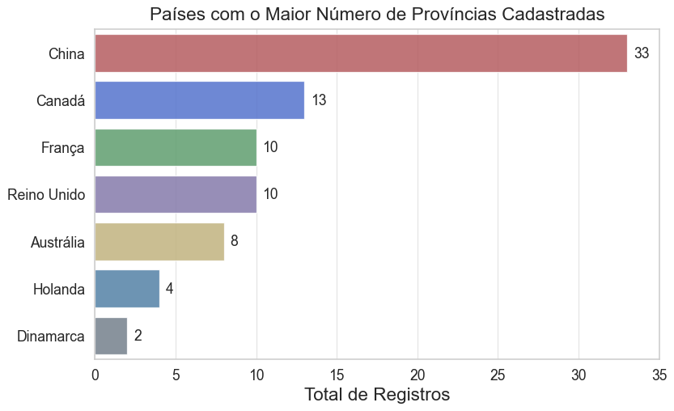

```python
# Exibe um gráfico de barras com esses valores

# Pega somente os valores maiores que 0
valores = regiao_df[regiao_df['Província/Estado'] != 0].sort_values('Província/Estado', ascending=False)

# Define as cores das barras
cores = ['r', 'royalblue', 'g', 'm', 'y', 'steelblue', 'slategray']

# Define o nome dos países
paises = ['China', 'Canadá', 'França', 'Reino Unido', 'Austrália', 'Holanda', 'Dinamarca']

# Plotagem
fig, ax = plt.subplots(figsize=(10, 6));

ax = sns.barplot(x='Província/Estado', y=valores.index, data=valores, palette=cores, alpha=0.85);
ax.set_xlim(0, 35);
ax.set_title("Países com o Maior Número de Províncias Cadastradas", fontsize = 18, y=1.01);
ax.set_xlabel("Total de Registros", fontsize=18);
ax.set_ylabel(None);
ax.set_yticklabels(paises);
ax.tick_params(axis='x', labelsize=14);
ax.tick_params(axis='y', labelsize=14);

# Exibe o total de cada país
show_values_on_bars(ax, 'h')

# Salva a figura
plt.savefig('imagens/maiores_provincias.png', dpi=300, transparent=True, bbox_inches='tight');
```

```python
# Conta o número de fatalidades para cada província ou estado, agrupando por país -> Somente para a China
covid_df[covid_df['País/Região'] == 'China'].groupby(['Código do País', 'Província/Estado'])['Fatalidades'].count()
```

```
Código do País  Província/Estado
CHN             Anhui               85
                Beijing             85
                Chongqing           85
                Fujian              85
                Gansu               85
                Guangdong           85
                Guangxi             85
                Guizhou             85
                Hainan              85
                Hebei               85
                Heilongjiang        85
                Henan               85
                Hong Kong           85
                Hubei               85
                Hunan               85
                Inner Mongolia      85
                Jiangsu             85
                Jiangxi             85
                Jilin               85
                Liaoning            85
                Macau               85
                Ningxia             85
                Qinghai             85
                Shaanxi             85
                Shandong            85
                Shanghai            85
                Shanxi              85
                Sichuan             85
                Tianjin             85
                Tibet               85
                Xinjiang            85
                Yunnan              85
                Zhejiang            85
Name: Fatalidades, dtype: int64
```

```python
# Conta o número de fatalidades para cada província ou estado, agrupando por país -> Somente para a Dinamarca
covid_df[covid_df['País/Região'] == 'Denmark'].groupby(['Código do País', 'Província/Estado'])['Fatalidades'].count()
```

```
Código do País  Província/Estado
DNK             Faroe Islands       85
                Greenland           85
Name: Fatalidades, dtype: int64
```

```python
# Conta o número de fatalidades para cada província ou estado, agrupando por país -> Somente para a Holanda
covid_df[covid_df['País/Região'] == 'Netherlands'].groupby(['Código do País', 'Província/Estado'])['Fatalidades'].value_counts()
```

```
Código do País  Província/Estado                  Fatalidades
NLD             Aruba                             0              84
                                                  1               1
                Bonaire, Sint Eustatius and Saba  0              85
                Curacao                           0              57
                                                  1              28
                Sint Maarten                      0              70
                                                  9               5
                                                  6               4
                                                  1               2
                                                  4               2
                                                  2               1
                                                  8               1
Name: Fatalidades, dtype: int64
```

## 3.4 Análise de distribuição

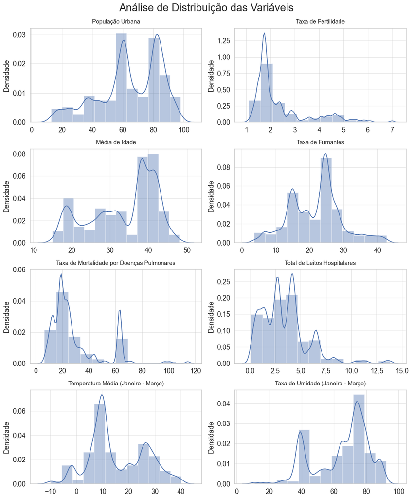

```python
# Exibe o gráfico de densidade de alguns atributos
# Com isso, podemos ter uma ideia da concentração da maior massa de valores

# Define as colunas
colunas = ['População Urbana', 'Taxa de Fertilidade', 'Média de Idade', 'Taxa de Fumantes',
           'Taxa de Mortalidade por Doenças Pulmonares', 'Total de Leitos Hospitalares',
           'Temperatura Média (Janeiro - Março)', 'Taxa de Umidade (Janeiro - Março)']

# Pega somente os valores das colunas desejadas
valores = covid_df[colunas]

# Plotagem
plt.figure(figsize=(12, 14))
plt.suptitle('Análise de Distribuição das Variáveis', fontsize=22, y=1.02)

for i,coluna in enumerate(colunas):
    ax = plt.subplot(4, 2, i + 1)
    sns.distplot(valores[coluna], kde=True, hist=True, norm_hist=False, bins=12);
    plt.title(coluna, y=1.02, fontsize=12);
    ax.set_xlabel(None)
    ax.set_ylabel('Densidade', fontsize=14)
    ax.tick_params(axis='x', labelsize=14)
    ax.tick_params(axis='y', labelsize=14)

# Ajusta o layout
plt.tight_layout();

# Salva a figura
plt.savefig('imagens/analise_distribuicao.png', dpi=300, transparent=True, bbox_inches='tight');
```

## 3.5 Verificando outliers com Boxplots

Um outlier pode indicar um erro nos dados (como um erro de digitação ou erro de medição, efeitos sazonais etc.). Nesse caso, ele deve ser corrigido ou removido dos dados antes de calcular estatísticas resumidas ou obter informações dos dados, sem as quais levará a análises incorretas.

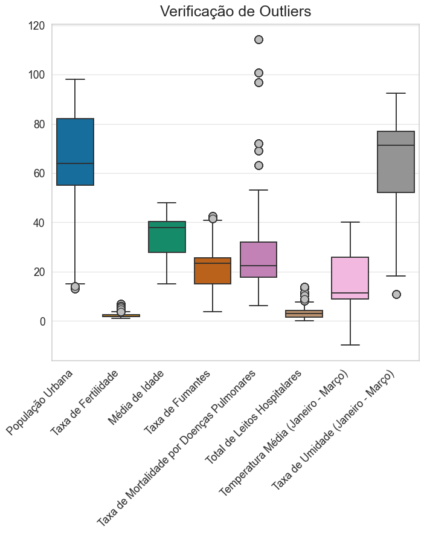

```python
# Verificando outliers

# Define as colunas
colunas = ['População Urbana', 'Taxa de Fertilidade', 'Média de Idade', 'Taxa de Fumantes',
           'Taxa de Mortalidade por Doenças Pulmonares', 'Total de Leitos Hospitalares',
           'Temperatura Média (Janeiro - Março)', 'Taxa de Umidade (Janeiro - Março)']

# Props para o boxplot
flierprops = dict(markerfacecolor='0.75', marker='o', markersize=10, linestyle='none')

# Pega somente os valores das colunas desejadas
valores = covid_df[colunas]

# Plotagem
fig, ax = plt.subplots(figsize=(8, 10));

sns.set(style='whitegrid');
ax = sns.boxplot(data=valores, orient='v', palette='colorblind', flierprops=flierprops);
ax.set_title("Verificação de Outliers", fontsize = 20, y=1.01);
ax.set_xticklabels(colunas, rotation=45, ha='right');
ax.tick_params(axis='x', labelsize=14, rotation=45);
ax.tick_params(axis='y', labelsize=14);

# Ajusta o layout
plt.tight_layout();

# Salva a figura
plt.savefig('imagens/outliers_gerais.png', dpi=300, transparent=True, bbox_inches='tight');
```

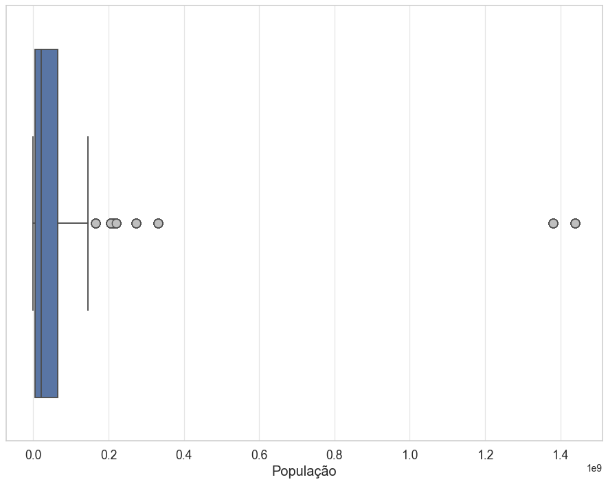

```python
# Outliers da População

# Props para o boxplot
flierprops = dict(markerfacecolor='0.75', marker='o', markersize=10, linestyle='none')

# Plotagem
sns.set(style="whitegrid");
sns.boxplot(y='População', data=covid_df, orient='h', color='b', flierprops=flierprops);
plt.xlabel('População', fontsize=16);
plt.xticks(fontsize=14);
plt.tight_layout();

# Salva a figura
plt.savefig('imagens/outliers_populacao.png', dpi=300, bbox_inches='tight');
```

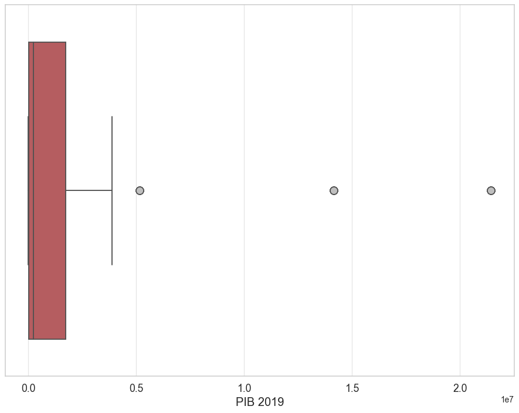

```python
# Outliers do PIB

# Props para o boxplot
flierprops = dict(markerfacecolor='0.75', marker='o', markersize=10, linestyle='none')

# Plotagem
sns.set(style="whitegrid");
sns.boxplot(y='PIB 2019', data=covid_df, orient='h', color='r', flierprops=flierprops);
plt.xlabel('PIB 2019', fontsize=16);
plt.xticks(fontsize=14);
plt.tight_layout();

# Salva a figura
plt.savefig('imagens/outliers_pib.png', dpi=300, bbox_inches='tight');
```

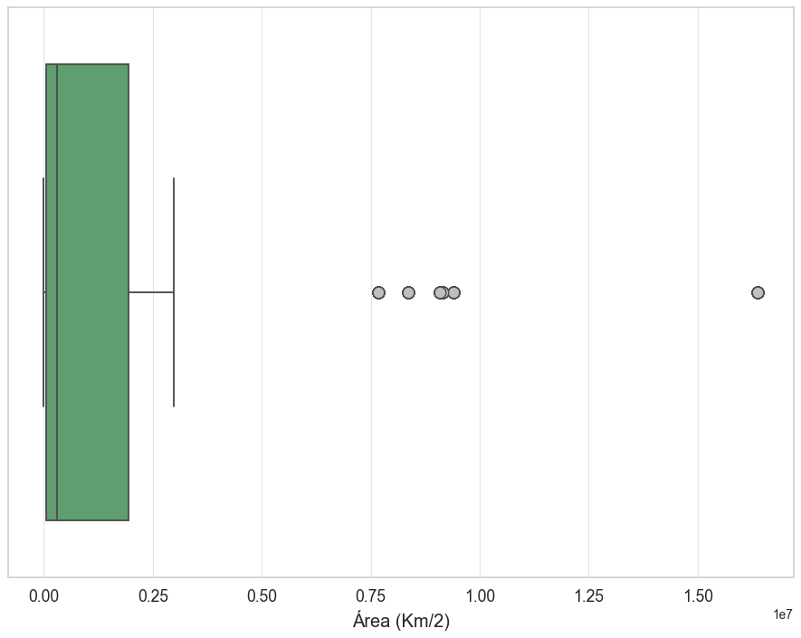

```python
# Outliers da Área

# Props para o boxplot
flierprops = dict(markerfacecolor='0.75', marker='o', markersize=10, linestyle='none')

# Plotagem
sns.set(style="whitegrid");
sns.boxplot(y='Área (Km/2)', data=covid_df, orient='h', color='g', flierprops=flierprops);
plt.xlabel('Área (Km/2)', fontsize=16);
plt.xticks(fontsize=14);
plt.tight_layout();

# Salva a figura
plt.savefig('imagens/outliers_area.png', dpi=300, bbox_inches='tight');
```

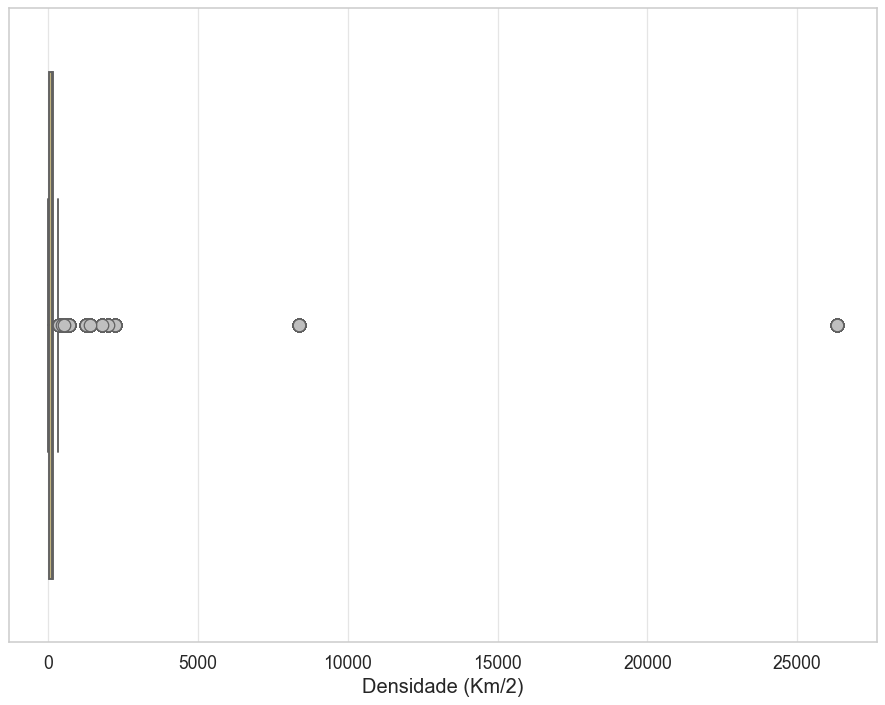

```python
# Outliers da Densidade

# Props para o boxplot
flierprops = dict(markerfacecolor='0.75', marker='o', markersize=10, linestyle='none')

# Plotagem
sns.set(style="whitegrid");
sns.boxplot(y='Densidade (Km/2)', data=covid_df, orient='h', color='y', flierprops=flierprops);
plt.xlabel('Densidade (Km/2)', fontsize=16);
plt.xticks(fontsize=14);
plt.tight_layout();

# Salva a figura
plt.savefig('imagens/outliers_densidade.png', dpi=300, bbox_inches='tight');
```

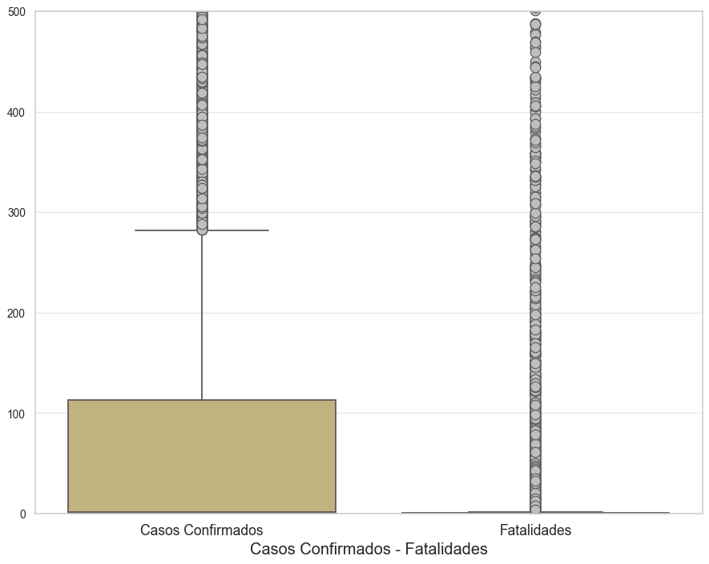

```python
# Outliers do número de caso confirmados e das fatalidades

# Props para o boxplot
flierprops = dict(markerfacecolor='0.75', marker='o', markersize=10, linestyle='none')

# Plotagem
sns.set(style="whitegrid");
sns.boxplot(data=covid_df[['Casos Confirmados', 'Fatalidades']], orient='v', color='y', flierprops=flierprops);
plt.xlabel('Casos Confirmados - Fatalidades', fontsize=16);
plt.xticks(fontsize=14);
plt.ylim(0, 500);
plt.tight_layout();

# Salva a figura
plt.savefig('imagens/outliers_casos_confirmados.png', dpi=300, bbox_inches='tight');
```

```python
# Estatísticas básicas relacionadas ao número de casos confirmados e ao número de fatalidades
covid_df[['Casos Confirmados', 'Fatalidades']].describe()
```

|  | Casos Confirmados | Fatalidades |
| --- | --- | --- |
| count | 22270.00 | 22270.00 |
| mean | 1481.74 | 79.56 |
| std | 14556.72 | 890.46 |
| min | 0.00 | 0.00 |
| 25% | 0.00 | 0.00 |
| 50% | 2.00 | 0.00 |
| 75% | 113.00 | 1.00 |
| max | 636350.00 | 28326.00 |

## 3.6 Verificando os valores nulos

Os valores ausentes no conjunto de dados referem-se aos campos vazios ou sem valores atribuídos a eles, geralmente ocorrem devido a erros de entrada de dados, falhas que ocorrem nos processos de coleta de dados e, muitas vezes, ao unir várias colunas de diferentes tabelas, encontramos uma condição que leva para valores ausentes. Existem inúmeras maneiras pelas quais os valores ausentes são tratados, sendo os mais fáceis substituir o valor ausente pela média, mediana, modo ou valor constante (chegamos a um valor baseado no conhecimento do domínio) e outra alternativa é remover a entrada do próprio conjunto de dados.

```python
# Verifica se existem valores nulos no DataFrame
covid_df.isnull().values.any()
```

```
True
```

```python
# Verifica o total de valores nulos no DataFrame
covid_df.isnull().sum()
```

```
Código do País                                 1275
País/Região                                       0
Província/Estado                              15470
Latitude                                          0
Longitude                                         0
PIB 2019                                       1275
População                                      1020
População Urbana                               1445
Área (Km/2)                                    1020
Densidade (Km/2)                               1020
Taxa de Fertilidade                            1530
Média de Idade                                 1530
Taxa de Fumantes                               5355
Taxa de Mortalidade por Doenças Pulmonares     1955
Total de Leitos Hospitalares                   1275
Temperatura Média (Janeiro - Março)            3655
Taxa de Umidade (Janeiro - Março)              3655
Data do Primeiro Caso                          1275
Data                                              0
Casos Confirmados                                 0
Fatalidades                                       0
dtype: int64
```

## 3.7 Matriz de Correlação

Uma matriz de correlação é uma tabela que mostra o valor do coeficiente de correlação (os coeficientes de correlação são usados nas estatísticas para medir a força de um relacionamento entre duas variáveis.) Entre conjuntos de variáveis. Cada atributo do conjunto de dados é comparado com outros atributos para descobrir o coeficiente de correlação. Essa análise permite ver quais pares têm a correlação mais alta, os pares que são altamente correlacionados representam a mesma variação do conjunto de dados, portanto, podemos analisá-los mais para entender qual atributo entre os pares é mais significativo para a construção do modelo.

Na rede de correlação de todas as variáveis selecionadas, o valor da correlação está entre -1 e +1. Variáveis altamente correlacionadas terão valor de correlação próximo a +1 e variáveis menos correlacionadas terão valor de correlação próximo a -1.

```python
# Define as colunas
colunas = ['PIB 2019', 'População', 'População Urbana', 'Área (Km/2)','Densidade (Km/2)', 'Taxa de Fertilidade', 'Média de Idade',
           'Taxa de Fumantes', 'Taxa de Mortalidade por Doenças Pulmonares', 'Total de Leitos Hospitalares',
           'Temperatura Média (Janeiro - Março)', 'Taxa de Umidade (Janeiro - Março)', 'Casos Confirmados', 'Fatalidades']

# Exibe a correlação de Pearson de algumas colunas
covid_df[colunas].corr()
```

|  | PIB 2019 | População | População Urbana | Área (Km/2) | Densidade (Km/2) | Taxa de Fertilidade | Média de Idade | Taxa de Fumantes | Taxa de Mortalidade por Doenças Pulmonares | Total de Leitos Hospitalares | Temperatura Média (Janeiro - Março) | Taxa de Umidade (Janeiro - Março) | Casos Confirmados | Fatalidades |
| --- | --- | --- | --- | --- | --- | --- | --- | --- | --- | --- | --- | --- | --- | --- |
| PIB 2019 | 1.00 | 0.95 | 0.01 | 0.76 | -0.05 | -0.28 | 0.29 | 0.14 | 0.69 | 0.19 | -0.28 | -0.59 | 0.12 | 0.06 |
| População | 0.95 | 1.00 | -0.08 | 0.73 | -0.04 | -0.23 | 0.20 | 0.14 | 0.77 | 0.12 | -0.20 | -0.67 | 0.03 | 0.01 |
| População Urbana | 0.01 | -0.08 | 1.00 | 0.13 | -0.01 | -0.54 | 0.61 | 0.08 | -0.29 | 0.32 | -0.33 | 0.26 | 0.06 | 0.05 |
| Área (Km/2) | 0.76 | 0.73 | 0.13 | 1.00 | -0.08 | -0.30 | 0.30 | -0.04 | 0.51 | 0.09 | -0.33 | -0.35 | 0.05 | 0.01 |
| Densidade (Km/2) | -0.05 | -0.04 | -0.01 | -0.08 | 1.00 | -0.11 | 0.10 | -0.05 | -0.05 | 0.30 | 0.03 | 0.00 | -0.01 | -0.01 |
| Taxa de Fertilidade | -0.28 | -0.23 | -0.54 | -0.30 | -0.11 | 1.00 | -0.89 | -0.35 | -0.05 | -0.52 | 0.55 | -0.14 | -0.06 | -0.06 |
| Média de Idade | 0.29 | 0.20 | 0.61 | 0.30 | 0.10 | -0.89 | 1.00 | 0.38 | -0.06 | 0.66 | -0.64 | 0.19 | 0.08 | 0.09 |
| Taxa de Fumantes | 0.14 | 0.14 | 0.08 | -0.04 | -0.05 | -0.35 | 0.38 | 1.00 | 0.10 | 0.47 | -0.25 | -0.07 | 0.01 | 0.02 |
| Taxa de Mortalidade por Doenças Pulmonares | 0.69 | 0.77 | -0.29 | 0.51 | -0.05 | -0.05 | -0.06 | 0.10 | 1.00 | -0.06 | -0.08 | -0.54 | 0.00 | -0.02 |
| Total de Leitos Hospitalares | 0.19 | 0.12 | 0.32 | 0.09 | 0.30 | -0.52 | 0.66 | 0.47 | -0.06 | 1.00 | -0.44 | 0.07 | 0.03 | 0.01 |
| Temperatura Média (Janeiro - Março) | -0.28 | -0.20 | -0.33 | -0.33 | 0.03 | 0.55 | -0.64 | -0.25 | -0.08 | -0.44 | 1.00 | -0.25 | -0.03 | -0.02 |
| Taxa de Umidade (Janeiro - Março) | -0.59 | -0.67 | 0.26 | -0.35 | 0.00 | -0.14 | 0.19 | -0.07 | -0.54 | 0.07 | -0.25 | 1.00 | -0.00 | -0.00 |
| Casos Confirmados | 0.12 | 0.03 | 0.06 | 0.05 | -0.01 | -0.06 | 0.08 | 0.01 | 0.00 | 0.03 | -0.03 | -0.00 | 1.00 | 0.85 |
| Fatalidades | 0.06 | 0.01 | 0.05 | 0.01 | -0.01 | -0.06 | 0.09 | 0.02 | -0.02 | 0.01 | -0.02 | -0.00 | 0.85 | 1.00 |

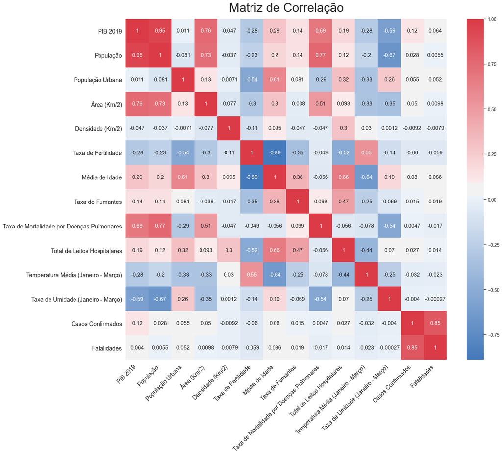

```python
# Plotagem da matriz de correlação

# Calcula a matriz de correlação
correlations = covid_df[colunas].corr()

# Mapa de cor
cmap = sns.diverging_palette(250, 10, as_cmap=True)

# Plotagem
plt.figure(figsize=(18, 15))

sns.heatmap(correlations, cmap=cmap,
            xticklabels=correlations.columns, yticklabels=correlations.columns,
            cbar=True,
            annot=True, annot_kws={'size': 13});

# Título
plt.suptitle('Matriz de Correlação', x=0.54, y=1.02, fontsize=30);

# Ajusta os labels
plt.xticks(rotation=45, ha='right', fontsize=14);
plt.yticks(fontsize=14);

# Ajusta o layout
plt.tight_layout();

# Salva a figura
plt.savefig('imagens/matriz_correlacao.png', dpi=300, transparent=True, bbox_inches='tight');
```